# Starbucks Capstone Challenge

This project (Data Scientist Capstone) is part of Udacity's Data Scientists Nanodegree Program. Detailed analysis with all required code is posted in my Github repository and Jupyter Notebook.

#### Note: all graphs in this post are interactive made with Plot.ly, feel free to play around with data yourself :)

## Project Overview:

One thing Starbuck does well is to keep customers satisfied, with increasing compition let us see if it it only a social phenomenon, or that Starbuck cares about gaining and maintaining customers loyalty!

The data provided by Starbuck, contains simulated data that mimics customer behavior on the Starbucks rewards mobile app. Once every few days, Starbucks sends out an offer to users of the mobile app. An offer can be merely an advertisement for a drink or an actual offer such as a discount or BOGO (buy one get one free). In this project we aim to use this dataset and analyze transactions, demographics, and offer portfolio to determine which group responds well to which offers.

## Problem Statement:

The goal of this project is to analyze customers behavior and interactions with special offers sent on the app. Firstly, we want to explore customers demographics, and customers transcript data. Further on, we will focus on customers interaction with offers. Finally, we will study these interactions by building a machine learning model that will cluster customers based on similar behaviors.

We will formulate the problem into the following set of questions that we will aim to answer as we go through the analysis:

1. Who are our customers, and their demographics?
2. What are the characteristics of custumers transcripts?
3. What are the characteristics of customers interactions with the offers?
4. What are the main customers segments based on their behavioral patterns?

## Metrics:

One approach to effectively target customers is by identifying customers segments and clustering similar behaviors into groups. Creating such model will help us in understanding how specific group will interact with which offer type. In order to achieve this result we will use KMeans as Unsupervised Machine Learning Model. KMeans is one of the simplest model where it will reveals underlying patterns by grouping similar data points together, without inference to known or labelled outcome. The matrix here will be Error Sum of Squares (SSE) which calculates the sum of the squared differences between each observation and its group's mean. It can be used as a measure of variation within a cluster.

Implementing this model will quickly gives us great insights about our customers, later on, we may choose to implement different clustering algorithm.

## Data Loading and Preprocessing:

### Data Sets

The data from Starbucks rewards app, is contained in three files:

- portfolio.json - containing offer ids and meta data about each offer (duration, type, etc.)
- profile.json - demographic data for each customer
- transcript.json - records for transactions, offers received, offers viewed, and offers completed

Here is the schema and explanation of each variable in the files:

**portfolio.json**

- id (string) - offer id
- offer_type (string) - type of offer ie BOGO, discount, informational
- difficulty (int) - minimum required spend to complete an offer
- reward (int) - reward given for completing an offer
- duration (int) - time for offer to be open, in days
- channels (list of strings)

**profile.json**

- age (int) - age of the customer
- became_member_on (int) - date when customer created an app account
- gender (str) - gender of the customer (note some entries contain 'O' for other rather than M or F)
- id (str) - customer id
- income (float) - customer's income

**transcript.json**

- event (str) - record description (ie transaction, offer received, offer viewed, etc.)
- person (str) - customer id
- time (int) - time in hours since start of test. The data begins at time t=0
- value - (dict of strings) - either an offer id or transaction amount depending on the record

```python
# load libraries
import pandas as pd
import numpy as np
import math
import json
from datetime import datetime
from time import time
import matplotlib.pyplot as plt
import seaborn as sns

# sklearn:
from sklearn.model_selection import GridSearchCV
from sklearn.metrics import make_scorer
from sklearn.model_selection import train_test_split
from sklearn.metrics import fbeta_score
from sklearn.metrics import accuracy_score
from sklearn.tree import DecisionTreeClassifier
from sklearn.ensemble import AdaBoostClassifier
from sklearn.ensemble import GradientBoostingClassifier
from sklearn.ensemble import RandomForestClassifier
from sklearn.preprocessing import MinMaxScaler
from sklearn.decomposition import PCA


# Plotly:
import plotly.plotly as py
import plotly
import plotly.graph_objs as go
from plotly import tools
import plotly.figure_factory as ff

import colorlover as cl

from IPython.display import HTML
from IPython.display import display
```

```python
# Configurations:
plotly.tools.set_credentials_file(username='rawanmm', api_key='9TIS4IOtNmEoHGTadSEh')
plotly.offline.init_notebook_mode(connected=True)
pd.options.display.max_columns = None
% matplotlib inline
bupu = cl.scales['9']['seq']['BuGn']
HTML( cl.to_html(bupu))
```

```python
# read in the json files
portfolio = pd.read_json('data/portfolio.json', orient='records', lines=True)
profile = pd.read_json('data/profile.json', orient='records', lines=True)
transcript = pd.read_json('data/transcript.json', orient='records', lines=True)
```

```python
profile.head()
```

|  | age | became_member_on | gender | id | income |
| --- | --- | --- | --- | --- | --- |
| 0 | 118 | 20170212 | None | 68be06ca386d4c31939f3a4f0e3dd783 | NaN |
| 1 | 55 | 20170715 | F | 0610b486422d4921ae7d2bf64640c50b | 112000.0 |
| 2 | 118 | 20180712 | None | 38fe809add3b4fcf9315a9694bb96ff5 | NaN |
| 3 | 75 | 20170509 | F | 78afa995795e4d85b5d9ceeca43f5fef | 100000.0 |
| 4 | 118 | 20170804 | None | a03223e636434f42ac4c3df47e8bac43 | NaN |

```python
profile.info()
```

```
<class 'pandas.core.frame.DataFrame'>
RangeIndex: 17000 entries, 0 to 16999
Data columns (total 5 columns):
age                 17000 non-null int64
became_member_on    17000 non-null int64
gender              14825 non-null object
id                  17000 non-null object
income              14825 non-null float64
dtypes: float64(1), int64(2), object(2)
memory usage: 664.1+ KB
```

```python
portfolio.head()
```

|  | channels | difficulty | duration | id | offer_type | reward |
| --- | --- | --- | --- | --- | --- | --- |
| 0 | [email, mobile, social] | 10 | 7 | ae264e3637204a6fb9bb56bc8210ddfd | bogo | 10 |
| 1 | [web, email, mobile, social] | 10 | 5 | 4d5c57ea9a6940dd891ad53e9dbe8da0 | bogo | 10 |
| 2 | [web, email, mobile] | 0 | 4 | 3f207df678b143eea3cee63160fa8bed | informational | 0 |
| 3 | [web, email, mobile] | 5 | 7 | 9b98b8c7a33c4b65b9aebfe6a799e6d9 | bogo | 5 |
| 4 | [web, email] | 20 | 10 | 0b1e1539f2cc45b7b9fa7c272da2e1d7 | discount | 5 |

```python
transcript.head()
```

|  | event | person | time | value |
| --- | --- | --- | --- | --- |
| 0 | offer received | 78afa995795e4d85b5d9ceeca43f5fef | 0 | {'offer id': '9b98b8c7a33c4b65b9aebfe6a799e6d9'} |
| 1 | offer received | a03223e636434f42ac4c3df47e8bac43 | 0 | {'offer id': '0b1e1539f2cc45b7b9fa7c272da2e1d7'} |
| 2 | offer received | e2127556f4f64592b11af22de27a7932 | 0 | {'offer id': '2906b810c7d4411798c6938adc9daaa5'} |
| 3 | offer received | 8ec6ce2a7e7949b1bf142def7d0e0586 | 0 | {'offer id': 'fafdcd668e3743c1bb461111dcafc2a4'} |
| 4 | offer received | 68617ca6246f4fbc85e91a2a49552598 | 0 | {'offer id': '4d5c57ea9a6940dd891ad53e9dbe8da0'} |

```python
transcript.tail()
```

|  | event | person | time | value |
| --- | --- | --- | --- | --- |
| 306529 | transaction | b3a1272bc9904337b331bf348c3e8c17 | 714 | {'amount': 1.5899999999999999} |
| 306530 | transaction | 68213b08d99a4ae1b0dcb72aebd9aa35 | 714 | {'amount': 9.53} |
| 306531 | transaction | a00058cf10334a308c68e7631c529907 | 714 | {'amount': 3.61} |
| 306532 | transaction | 76ddbd6576844afe811f1a3c0fbb5bec | 714 | {'amount': 3.5300000000000002} |
| 306533 | transaction | c02b10e8752c4d8e9b73f918558531f7 | 714 | {'amount': 4.05} |

```python
transcript.info()
```

```
<class 'pandas.core.frame.DataFrame'>
RangeIndex: 306534 entries, 0 to 306533
Data columns (total 4 columns):
event     306534 non-null object
person    306534 non-null object
time      306534 non-null int64
value     306534 non-null object
dtypes: int64(1), object(3)
memory usage: 9.4+ MB
```

### Data Cleaning and Preprocessing:

##### Data Preprocessing:

the data is contained in json objects which easily can be loaded in Pandas Dataframe, however for (transcript.json) we have nested objects so we proccesed this data to ensure we have all data presented in clean stracture:

##### Feature Transformation:

we constructed new features related to customer membership dates, such as (Year, Month, and Loyalty). In portofolio dataset we have calculated useful matrices such as; the completion rate, view rate, average completion time based on customer transactions data, which will be referenced in the next section.

##### Data Cleaning:

the datasets are mostly in good shape, however there are some outliers in missing data points in profile dataset. It's handled by either dropping the row or imputing with mean. Finally, we have prepared to merge all three datasets into one dataframe, which will be useful to draw relations between customers, offers and transactions.

```python
# method to clean profile dataset:
def clean_profile(profile):
    profile.gender.fillna('N', inplace=True)
    profile.age.replace(118, np.NaN, inplace=True)
    profile.income.fillna(profile.income.mean(), inplace=True)

    profile.dropna(inplace=True)

    profile.became_member_on = profile.became_member_on.apply(lambda x: datetime.strptime(str(x), '%Y%m%d'))
    profile['year'] = profile.became_member_on.dt.year
    profile['month'] = profile.became_member_on.dt.month
    profile['loyalty'] = (2019 - profile.year).astype(int)
    profile.rename(columns={'id': 'persone_id'}, inplace=True)

    return profile
```

```python
# method to clean transcript dataset:
def clean_transcript(transcript):
    transcript = pd.concat([transcript, transcript['value'].apply(pd.Series)], axis = 1).drop('value', axis = 1)
    transcript['offer_id'].fillna(transcript['offer id'], inplace=True)
    transcript.drop('offer id', axis = 1, inplace=True)
    transcript.rename(columns={'person': 'persone_id'}, inplace=True)
    transcript['day'] = round(transcript.time/24).astype(int)
    return transcript
```

```python
# method to clean portfolio dataset:
def clean_portfolio(portfolio):
    portfolio = portfolio.drop('channels', 1).join(
    pd.get_dummies(
        pd.DataFrame(portfolio.channels.tolist()).stack()
    ).astype(int).sum(level=0))
    portfolio.rename(columns={'id': 'offer_id', 'reward': 'offer_reward'}, inplace=True)
    return portfolio
```

```python
# method to merge three datasets into one:
def merged_datafram(profile, transcript, portfolio):
    df = pd.merge(transcript, profile, on='persone_id')
    df = pd.merge(df, portfolio, on='offer_id', how='left')
    return df
```

```python
profile.isnull().sum(axis = 0)/profile.shape[0]*100
```

```
age                  0.000000
became_member_on     0.000000
gender              12.794118
id                   0.000000
income              12.794118
dtype: float64
```

```python
profile = clean_profile(profile)
```

```python
transcript = clean_transcript(transcript)
```

```python
portfolio = clean_portfolio(portfolio)
```

```python
profile.isnull().sum(axis = 0)
```

```
age                 0
became_member_on    0
gender              0
persone_id          0
income              0
year                0
month               0
loyalty             0
dtype: int64
```

```python
transcript.isnull().sum(axis = 0)
```

```
event              0
persone_id         0
time               0
amount        167581
offer_id      138953
reward        272955
day                0
dtype: int64
```

```python
portfolio.isnull().sum(axis = 0)
```

```
difficulty      0
duration        0
offer_id        0
offer_type      0
offer_reward    0
email           0
mobile          0
social          0
web             0
dtype: int64
```

```python
portfolio.head()
```

|  | difficulty | duration | offer_id | offer_type | offer_reward | email | mobile | social | web |
| --- | --- | --- | --- | --- | --- | --- | --- | --- | --- |
| 0 | 10 | 7 | ae264e3637204a6fb9bb56bc8210ddfd | bogo | 10 | 1 | 1 | 1 | 0 |
| 1 | 10 | 5 | 4d5c57ea9a6940dd891ad53e9dbe8da0 | bogo | 10 | 1 | 1 | 1 | 1 |
| 2 | 0 | 4 | 3f207df678b143eea3cee63160fa8bed | informational | 0 | 1 | 1 | 0 | 1 |
| 3 | 5 | 7 | 9b98b8c7a33c4b65b9aebfe6a799e6d9 | bogo | 5 | 1 | 1 | 0 | 1 |
| 4 | 20 | 10 | 0b1e1539f2cc45b7b9fa7c272da2e1d7 | discount | 5 | 1 | 0 | 0 | 1 |

```python
profile.head()
```

|  | age | became_member_on | gender | persone_id | income | year | month | loyalty |
| --- | --- | --- | --- | --- | --- | --- | --- | --- |
| 1 | 55.0 | 2017-07-15 | F | 0610b486422d4921ae7d2bf64640c50b | 112000.0 | 2017 | 7 | 2 |
| 3 | 75.0 | 2017-05-09 | F | 78afa995795e4d85b5d9ceeca43f5fef | 100000.0 | 2017 | 5 | 2 |
| 5 | 68.0 | 2018-04-26 | M | e2127556f4f64592b11af22de27a7932 | 70000.0 | 2018 | 4 | 1 |
| 8 | 65.0 | 2018-02-09 | M | 389bc3fa690240e798340f5a15918d5c | 53000.0 | 2018 | 2 | 1 |
| 12 | 58.0 | 2017-11-11 | M | 2eeac8d8feae4a8cad5a6af0499a211d | 51000.0 | 2017 | 11 | 2 |

```python
transcript.head()
```

|  | event | persone_id | time | amount | offer_id | reward | day |
| --- | --- | --- | --- | --- | --- | --- | --- |
| 0 | offer received | 78afa995795e4d85b5d9ceeca43f5fef | 0 | NaN | 9b98b8c7a33c4b65b9aebfe6a799e6d9 | NaN | 0 |
| 1 | offer received | a03223e636434f42ac4c3df47e8bac43 | 0 | NaN | 0b1e1539f2cc45b7b9fa7c272da2e1d7 | NaN | 0 |
| 2 | offer received | e2127556f4f64592b11af22de27a7932 | 0 | NaN | 2906b810c7d4411798c6938adc9daaa5 | NaN | 0 |
| 3 | offer received | 8ec6ce2a7e7949b1bf142def7d0e0586 | 0 | NaN | fafdcd668e3743c1bb461111dcafc2a4 | NaN | 0 |
| 4 | offer received | 68617ca6246f4fbc85e91a2a49552598 | 0 | NaN | 4d5c57ea9a6940dd891ad53e9dbe8da0 | NaN | 0 |

### Exploratory Data Analysis:

In this section we will conduct univarate and multivarete analysis to answer business questions:

##### 1- Who are our customers, and what are their demographics?

```python
# plot customer age against gender:
trace_2 = go.Histogram(
            x=profile[profile.gender == 'M'].age,
            name = 'Male',
            marker=dict(color = bupu[5]))

trace_1 = go.Histogram(
            x=profile[profile.gender == 'F'].age,
            name = 'Female',
            marker=dict(color = bupu[1]))

trace_3 = go.Histogram(
            x=profile[profile.gender == 'O'].age,
            name = 'Other',
            marker=dict(color = bupu[7]))

layout = go.Layout(title="Customers Age and Gender",
                        barmode='overlay',
                        xaxis = dict(ticks='', nticks=48,
                                    title=go.layout.xaxis.Title(
                                    text='Age'), automargin=True),
                        yaxis = dict(title=go.layout.yaxis.Title(
                                    text='Count'), automargin=True))


fig = go.Figure(data=[trace_1, trace_2, trace_3], layout=layout)


plotly.offline.iplot(fig)

#py.iplot(fig, filename='profile_age')
```

[interactive chart not shown]

###### Graph Reflection:

We can look at the from different presepectives, these graphs will gives us a general idea about demographics, ages, income, with respect to gender. Clearly Females represent higher percentage of the cutomers.

```python
# plot customer income against gender:
trace_1 = go.Box(
            y=profile[profile.gender == 'F'].income,
            name = 'Female',
            marker=dict(color = bupu[3]))

trace_2 = go.Box(
            y=profile[profile.gender == 'M'].income,
            name = 'Male',
            marker=dict(color = bupu[5]))

trace_3 = go.Box(
            y=profile[profile.gender == 'M'].income,
            name = 'Other',
            marker=dict(color = bupu[7]))

layout = go.Layout(title="Customers Income and Gender",
                        xaxis = dict(ticks='', nticks=48,
                                    title=go.layout.xaxis.Title(
                                    text='Gender'), automargin=True))

fig = go.Figure(data=[trace_1, trace_2, trace_3], layout=layout)

plotly.offline.iplot(fig)
#py.iplot(fig, filename='profile_income')
```

[interactive chart not shown]

###### Graph Reflection:

This graph shows box plot of Income with respect to Gender, Females have higher income distrubtion.

```python
# plot customer membership based on month and year:
customers_data_month = profile.groupby('became_member_on')['month'].count().reset_index()
customers_data_month = customers_data_month.set_index('became_member_on')
customers_data_month = customers_data_month['month'].resample('MS').sum()

trace_4 = go.Scatter(x=customers_data_month.index,
                     y=customers_data_month,
                     name='Total',
                     mode='lines+markers',
                    marker=dict(
                    color=bupu[7]))

layout = go.Layout(title="Customers Trends Per Months",
                        barmode='overlay',
                        xaxis = dict(ticks='', nticks=60,
                                    title=go.layout.xaxis.Title(
                                    text='Date')),
                        yaxis = dict(title=go.layout.yaxis.Title(
                                    text='Count')))


fig = go.Figure(data=[trace_4], layout=layout)

plotly.offline.iplot(fig)

#py.iplot(fig, filename='Customers_Trends_Per_Months')
```

[interactive chart not shown]

```python
customers_per_year_total = profile.became_member_on.groupby([profile.year]).count()
customers_per_year_female = profile[profile.gender == 'F'].became_member_on.groupby([profile.year]).count()
customers_per_year_male = profile[profile.gender == 'M'].became_member_on.groupby([profile.year]).count()
customers_per_year_other = profile[profile.gender == 'O'].became_member_on.groupby([profile.year]).count()


trace_1 = go.Bar(
    x = customers_per_year_total.index,
    y = customers_per_year_female,
    name = 'Female',
    #mode = 'lines',
    #legendgroup= 'group2',
    marker=dict(
            color=bupu[2])
)



trace_2 = go.Bar(
    x = customers_per_year_total.index,
    y = customers_per_year_male,
    name = 'Male',
    #mode = 'lines',
    #legendgroup= 'group2',
    marker=dict(
            color=bupu[4])
)


trace_3 = go.Bar(
    x = customers_per_year_total.index,
    y = customers_per_year_other,
    name = 'Other',
    marker=dict(
            color=bupu[6])
)

trace_4 = go.Scatter(
    x = customers_per_year_total.index,
    y = customers_per_year_total,
    name = 'Total per year',
    mode = 'lines+markers',
    #legendgroup= 'group2',
    marker=dict(
            color=bupu[6])
)

layout = go.Layout(title="Customers Per Year",
                        barmode='group',
                        xaxis = dict(ticks='', nticks=8,
                                    title=go.layout.xaxis.Title(
                                    text='Year')),
                        yaxis = dict(title=go.layout.yaxis.Title(
                                    text='Count')))

fig = go.Figure(data=[trace_1, trace_2, trace_3 ,trace_4], layout=layout)
plotly.offline.iplot(fig)

#py.iplot(fig, filename='Customers_Per_Year')
```

[interactive chart not shown]

###### Graph Reflection:

These two graphs show how well Starbucks App is doing in term of aquiring new cusmters, we can see it increased in popularity in 2017, probably cuased by new lauched campaign? Another interesting pattern is the rise of customers in Octoper-December, the holiday season is always great hit for Starbucks.

##### 2- What are the characteristics of cutomers transcripts?

This quesion lead to many new questions that will mainly be answerd from transcripts dataset. The data here is record of every transaction in the app, it contains four type of possible events (offer received, offer viewed, transaction, offer completed).

```python
transcript.head()
```

|  | event | persone_id | time | amount | offer_id | reward | day |
| --- | --- | --- | --- | --- | --- | --- | --- |
| 0 | offer received | 78afa995795e4d85b5d9ceeca43f5fef | 0 | NaN | 9b98b8c7a33c4b65b9aebfe6a799e6d9 | NaN | 0 |
| 1 | offer received | a03223e636434f42ac4c3df47e8bac43 | 0 | NaN | 0b1e1539f2cc45b7b9fa7c272da2e1d7 | NaN | 0 |
| 2 | offer received | e2127556f4f64592b11af22de27a7932 | 0 | NaN | 2906b810c7d4411798c6938adc9daaa5 | NaN | 0 |
| 3 | offer received | 8ec6ce2a7e7949b1bf142def7d0e0586 | 0 | NaN | fafdcd668e3743c1bb461111dcafc2a4 | NaN | 0 |
| 4 | offer received | 68617ca6246f4fbc85e91a2a49552598 | 0 | NaN | 4d5c57ea9a6940dd891ad53e9dbe8da0 | NaN | 0 |

```python
# plots distribution of events in trascript dataset:
events_distibution = transcript.event.groupby([transcript.event]).count().sort_values()

trace_4 = go.Bar(
    x = events_distibution.index,
    y = events_distibution,
    name = 'Events',
    #mode = 'lines',
    legendgroup= 'group2',
    marker=dict(
            color=bupu[3:])
)

layout = go.Layout(title="Event Distibutions",
                        xaxis = dict(ticks='', nticks=8,
                                    title=go.layout.xaxis.Title(
                                    text='Year'), automargin=True),
                        yaxis = dict(title=go.layout.yaxis.Title(
                                    text='Count')))

fig = go.Figure(data=[trace_4], layout=layout)
plotly.offline.iplot(fig)

#py.iplot(fig, filename='Accidents_Severity_Per_Year')
```

[interactive chart not shown]

###### Graph Reflection:

Transactions account for ~45% of records, followed by offer recieved, and offer viewed, and lastly offer completed with ~10% (which indicates that customer has achieved the required amount to benefit from the offer).

##### - What is the completion rate and view rate of offers?

One important aspect of any offer campaign is to measure the visibilty rate and completion rate of the sent offer, it is calculated as:

offer_visibilty = offers viewed/offers recieved

offer_completion = offers completed/offers recieved

```python
# method to calculate offer_completion, and offer_visibilty:
def calculate_offer_matrix(portfolio):
    offer_visibilty = transcript[transcript.event == 'offer viewed'].groupby([transcript.offer_id])['event'].count()/transcript[transcript.event == 'offer received'].groupby([transcript.offer_id])['event'].count()*100
    offer_completion = transcript[transcript.event == 'offer completed'].groupby([transcript.offer_id])['event'].count()/transcript[transcript.event == 'offer received'].groupby([transcript.offer_id])['event'].count()*100
    portfolio = pd.merge(portfolio,offer_completion, on='offer_id', how='left')
    portfolio = pd.merge(portfolio,offer_visibilty, on='offer_id', how='left')
    portfolio.rename(columns={'event_x': 'offer_completion', 'event_y': 'offer_visibilty'}, inplace=True)
    return portfolio
```

```python
portfolio = calculate_offer_matrix(portfolio)
portfolio
```

|  | difficulty | duration | offer_id | offer_type | offer_reward | email | mobile | social | web | offer_completion | offer_visibilty |
| --- | --- | --- | --- | --- | --- | --- | --- | --- | --- | --- | --- |
| 0 | 10 | 7 | ae264e3637204a6fb9bb56bc8210ddfd | bogo | 10 | 1 | 1 | 1 | 0 | 48.158788 | 87.699138 |
| 1 | 10 | 5 | 4d5c57ea9a6940dd891ad53e9dbe8da0 | bogo | 10 | 1 | 1 | 1 | 1 | 43.869353 | 96.114843 |
| 2 | 0 | 4 | 3f207df678b143eea3cee63160fa8bed | informational | 0 | 1 | 1 | 0 | 1 | NaN | 54.404621 |
| 3 | 5 | 7 | 9b98b8c7a33c4b65b9aebfe6a799e6d9 | bogo | 5 | 1 | 1 | 0 | 1 | 56.714863 | 54.331119 |
| 4 | 20 | 10 | 0b1e1539f2cc45b7b9fa7c272da2e1d7 | discount | 5 | 1 | 0 | 0 | 1 | 44.600939 | 34.728743 |
| 5 | 7 | 7 | 2298d6c36e964ae4a3e7e9706d1fb8c2 | discount | 3 | 1 | 1 | 1 | 1 | 67.433952 | 95.958671 |
| 6 | 10 | 10 | fafdcd668e3743c1bb461111dcafc2a4 | discount | 2 | 1 | 1 | 1 | 1 | 69.988153 | 96.445966 |
| 7 | 0 | 3 | 5a8bc65990b245e5a138643cd4eb9837 | informational | 0 | 1 | 1 | 1 | 0 | NaN | 87.778945 |
| 8 | 5 | 5 | f19421c1d4aa40978ebb69ca19b0e20d | bogo | 5 | 1 | 1 | 1 | 1 | 56.742835 | 95.945053 |
| 9 | 10 | 7 | 2906b810c7d4411798c6938adc9daaa5 | discount | 2 | 1 | 1 | 0 | 1 | 52.633648 | 53.957023 |

```python
# plot completetion rate with respect to visibilty rate:
trace_1 = go.Bar(
    x = portfolio.offer_id + " - " + portfolio.offer_type,
    y = portfolio.offer_completion,
    name = 'offer_completion',
    marker=dict(
            color=bupu[6])
)

trace_2 = go.Bar(
    x = portfolio.offer_id + " - " + portfolio.offer_type,
    y = portfolio.offer_visibilty,
    name = 'offer_visibilty',
    marker=dict(
            color=bupu[4])
)

layout = go.Layout(title="Offer Completion",
                        xaxis = dict(ticks='', nticks=12,
                                    title=go.layout.xaxis.Title(
                                    text='offer'), automargin=True),
                        yaxis = dict(title=go.layout.yaxis.Title(
                                    text='Percentage %')))

fig = go.Figure(data=[trace_1, trace_2], layout=layout)
plotly.offline.iplot(fig)

#py.iplot(fig, filename='Accidents_Severity_Per_Year')
```

[interactive chart not shown]

###### Graph Reflection:

We can see no correlation between viewing rate and completion rate, which may confirm the hypothesis that customers complete offers out of normal purchase habits without the influnce of offers.

##### - What is the customers retention rate, and customer churn rate?

Customer churn rate, refers to the action of losing a custmer, and customer retention rate, is the retained customers. There are many equations to calculate these variables, since it plays major difference in the commerce industry, as we want to minimise the customer churn rate and maximise the retention rate. In this graph we can see a count of how many customers lost/gained in a given day, based on transactions data:

```python
# method to get new customers:
# new customer who makes a transaction without having any previous transactions:
def get_new_customers(df):
    new_customers = {}
    all_customer = []
    for i ,row in df.iterrows():
        day_customers = transcript[(transcript.event == 'transaction') & (transcript.day == i)].persone_id.unique()
        new_customers[i] = len(set(day_customers).difference(set(all_customer)))
        all_customer.extend(day_customers)
    return new_customers
```

```python
# method to get lost customers:
# lost customer who no longer makes a transaction in the remaining of simulation period:
def get_lost_customers(df):
    lost_customers = {}
    days = len(df)
    for i ,row in df.iterrows():
        all_customers = []
        day_customers = transcript[(transcript.event == 'transaction') & (transcript.day == i)].persone_id.unique()
        for x in range(i+1, days):
            all_customers.extend(transcript[(transcript.event == 'transaction') & (transcript.day == x)].persone_id.unique())
        lost_customers[i] = len(set(day_customers).difference(set(all_customers)))
    return lost_customers
```

```python
# method to constuct dataframe of daily customers habits:
def get_daily_customers():
    daily_customers = pd.pivot_table(transcript[transcript.event == 'transaction'], values=['event', 'amount'], index=['day'],
                    aggfunc={'day': 'count',
                            'amount': np.sum})

    daily_customers['new_customers'] = list(get_new_customers(daily_customers).values())
    daily_customers['lost_customers'] = list(get_lost_customers(daily_customers).values())
    return daily_customers
```

```python
daily_customers = get_daily_customers()
daily_customers
```

| day | amount | day | new_customers | lost_customers |
| --- | --- | --- | --- | --- |
| 0 | 30088.74 | 2280 | 2098 | 1 |
| 1 | 38192.13 | 2829 | 1990 | 0 |
| 2 | 65682.45 | 5161 | 2713 | 3 |
| 3 | 34665.78 | 3090 | 1194 | 0 |
| 4 | 63101.94 | 4918 | 1494 | 1 |
| 5 | 32925.72 | 2762 | 696 | 2 |
| 6 | 52719.32 | 4048 | 916 | 6 |
| 7 | 33444.34 | 2793 | 611 | 4 |
| 8 | 74370.72 | 5709 | 1005 | 14 |
| 9 | 48529.05 | 3737 | 498 | 10 |
| 10 | 72523.77 | 5702 | 570 | 15 |
| 11 | 38626.59 | 3161 | 260 | 12 |
| 12 | 59529.83 | 4760 | 402 | 33 |
| 13 | 33485.93 | 2637 | 203 | 36 |
| 14 | 62327.61 | 4996 | 325 | 70 |
| 15 | 45563.50 | 3606 | 186 | 54 |
| 16 | 79731.15 | 6319 | 237 | 123 |
| 17 | 53093.21 | 4061 | 145 | 101 |
| 18 | 92761.03 | 7301 | 224 | 208 |
| 19 | 52383.25 | 4193 | 118 | 180 |
| 20 | 82050.50 | 6617 | 147 | 356 |
| 21 | 47115.62 | 3873 | 90 | 300 |
| 22 | 94897.01 | 7076 | 121 | 675 |
| 23 | 55603.86 | 4054 | 64 | 530 |
| 24 | 89961.93 | 6906 | 67 | 1198 |
| 25 | 56197.84 | 4411 | 38 | 936 |
| 26 | 92957.37 | 7110 | 57 | 2237 |
| 27 | 47982.10 | 3876 | 24 | 1643 |
| 28 | 77326.30 | 5996 | 38 | 3535 |
| 29 | 43640.64 | 3102 | 29 | 2490 |
| 30 | 23972.74 | 1869 | 18 | 1805 |

```python
# plot daily customer interactins (lost/new) for the simulation period:
trace_3 = go.Bar(x=daily_customers.index,
                     y=daily_customers.new_customers,
                     name='New Customers',
                     #mode='lines+markers',
                    marker=dict(
                    color=bupu[3]))

trace_4 = go.Bar(x=daily_customers.index,
                     y=daily_customers.lost_customers,
                     name='Lost Customers',
                     #mode='lines',
                    marker=dict(
                    color=bupu[7]))


layout = go.Layout(title="Customer Trends Per Day",
                        barmode='overlay',
                        xaxis = dict(ticks='', nticks=60,
                                    title=go.layout.xaxis.Title(
                                    text='Day')),
                        yaxis = dict(title=go.layout.yaxis.Title(
                                    text='Count')),
                        yaxis3=dict(title="yaxis4 title", anchor="x",
                            overlaying="y",side="right"))


fig = go.Figure(data=[trace_3,trace_4], layout=layout)

plotly.offline.iplot(fig)

#py.iplot(fig, filename='Customer_Trends_Per_Day')
```

[interactive chart not shown]

###### Graph Reflection:

Obviously, this is not an actual indicator of any alerming situation, since the data is simulated and set at fixed timeframe, yet it will be extremely valuable when set on real data for analysis.

```python
# plot daily transactions and amount:
trace_1 = go.Scatter(x=daily_customers.index,
                     y=daily_customers.amount,
                     name='Sales',
                     mode='lines',
                    marker=dict(
                    color=bupu[7]))

trace_2 = go.Scatter(x=daily_customers.index,
                     y=daily_customers.day,
                     name='Transactions',
                     mode='lines+markers',
                    marker=dict(
                    color=bupu[3]), yaxis="y3")

layout = go.Layout(title="Sales Trends Per Day",
                        barmode='overlay',
                        legend_orientation="h",
                        xaxis = dict(ticks='', nticks=60,
                                    title=go.layout.xaxis.Title(
                                    text='Day')),
                        yaxis = dict(title=go.layout.yaxis.Title(
                                    text='Transactions')),
                        yaxis3=dict(title="Sales", anchor="x", nticks=15,
                            overlaying="y",side="right", automargin=True, position=0.10))


fig = go.Figure(data=[trace_1,trace_2], layout=layout)

plotly.offline.iplot(fig)

#py.iplot(fig, filename='Sales_Trends_Per_Day')
```

[interactive chart not shown]

###### Graph Reflection:

It would be far more suprising we it was based on real time dataset!

###### - What is the average completion time of an offer?

```python
# method to calculate the average offer completion time in days:
def calculate_offer_completion(portfolio):
    transcript_completion = pd.pivot_table(transcript[transcript.event.isin(['offer completed', 'offer received'])], values=['day',], index=['offer_id', 'persone_id', 'event'],
                    aggfunc={'day': np.sum}).unstack()
    transcript_completion['day', 'completion_time'] = transcript_completion.day['offer completed'] - transcript_completion.day['offer received']
    transcript_completion.reset_index(inplace=True)
    transcript_completion[transcript_completion.day['completion_time'] < 0] = np.NaN
    transcript_completion.dropna(inplace=True)

    transcript_completion = transcript_completion.groupby([transcript_completion.offer_id]).mean()
    transcript_completion = transcript_completion.day
    transcript_completion.drop(['offer completed','offer received'], axis=1, inplace=True)

    portfolio = pd.merge(portfolio,transcript_completion, left_on='offer_id', right_on=transcript_completion.index, how='left')
    return portfolio
```

```python
portfolio = calculate_offer_completion(portfolio)
portfolio
```

|  | difficulty | duration | offer_id | offer_type | offer_reward | email | mobile | social | web | offer_completion | offer_visibilty | completion_time |
| --- | --- | --- | --- | --- | --- | --- | --- | --- | --- | --- | --- | --- |
| 0 | 10 | 7 | ae264e3637204a6fb9bb56bc8210ddfd | bogo | 10 | 1 | 1 | 1 | 0 | 48.158788 | 87.699138 | 2.645161 |
| 1 | 10 | 5 | 4d5c57ea9a6940dd891ad53e9dbe8da0 | bogo | 10 | 1 | 1 | 1 | 1 | 43.869353 | 96.114843 | 2.033716 |
| 2 | 0 | 4 | 3f207df678b143eea3cee63160fa8bed | informational | 0 | 1 | 1 | 0 | 1 | NaN | 54.404621 | NaN |
| 3 | 5 | 7 | 9b98b8c7a33c4b65b9aebfe6a799e6d9 | bogo | 5 | 1 | 1 | 0 | 1 | 56.714863 | 54.331119 | 2.786039 |
| 4 | 20 | 10 | 0b1e1539f2cc45b7b9fa7c272da2e1d7 | discount | 5 | 1 | 0 | 0 | 1 | 44.600939 | 34.728743 | 4.931047 |
| 5 | 7 | 7 | 2298d6c36e964ae4a3e7e9706d1fb8c2 | discount | 3 | 1 | 1 | 1 | 1 | 67.433952 | 95.958671 | 2.749941 |
| 6 | 10 | 10 | fafdcd668e3743c1bb461111dcafc2a4 | discount | 2 | 1 | 1 | 1 | 1 | 69.988153 | 96.445966 | 3.549977 |
| 7 | 0 | 3 | 5a8bc65990b245e5a138643cd4eb9837 | informational | 0 | 1 | 1 | 1 | 0 | NaN | 87.778945 | NaN |
| 8 | 5 | 5 | f19421c1d4aa40978ebb69ca19b0e20d | bogo | 5 | 1 | 1 | 1 | 1 | 56.742835 | 95.945053 | 1.999710 |
| 9 | 10 | 7 | 2906b810c7d4411798c6938adc9daaa5 | discount | 2 | 1 | 1 | 0 | 1 | 52.633648 | 53.957023 | 3.088490 |

```python
# plot the customers average completion time against offer duration:
x = portfolio[portfolio.completion_time.notna()]

trace_1 = go.Scatter(x=x.offer_id + " - " + x.offer_type,
                     y=x.duration,
                     name='Offer Duration',
                     mode='lines',
                    marker=dict(
                    color=bupu[5]))

trace_2 = go.Bar(
    x = x.offer_id + " - " + x.offer_type,
    y = x.completion_time,
    name = 'offer_time_completion',
    marker=dict(
            color=bupu[1:])
)

layout = go.Layout(title="Offer Time Completion vs. Offer Duration",
                        xaxis = dict(ticks='', nticks=12,
                                    title=go.layout.xaxis.Title(
                                    text='offer'), automargin=True),
                        yaxis = dict(title=go.layout.yaxis.Title(
                                    text='Days')))

fig = go.Figure(data=[trace_1, trace_2], layout=layout)
plotly.offline.iplot(fig)

#py.iplot(fig, filename='Offer_Time_Completion')
```

[interactive chart not shown]

###### Graph Reflection:

This will gives us an estimation of how long we should run an offer, for example if the majority of custmers will complete the offer in more than 50% the spesified time it means the initial estimate was invalid and we could be running new offers to enhance customer engagements.

#### 3- What are the characteristics of customers interactions with the offers?

There are many aspects we can look at when considering customer and offer iteractions, however we will focus on Age, and Loyalty and how it reflected on transactions and completion of offers.

```python
# get merged dataframe to perform complete analysis:
df = merged_datafram(profile, transcript, portfolio)
```

```python
df[df.event=='transaction'].isnull().sum(axis = 0)
```

```
event                    0
persone_id               0
time                     0
amount                   0
offer_id            123957
reward              123957
day                      0
age                      0
became_member_on         0
gender                   0
income                   0
year                     0
month                    0
loyalty                  0
difficulty          123957
duration            123957
offer_type          123957
offer_reward        123957
email               123957
mobile              123957
social              123957
web                 123957
offer_completion    123957
offer_visibilty     123957
completion_time     123957
dtype: int64
```

```python
df.head()
```

|  | event | persone_id | time | amount | offer_id | reward | day | age | became_member_on | gender | income | year | month | loyalty | difficulty | duration | offer_type | offer_reward | email | mobile | social | web | offer_completion | offer_visibilty | completion_time |
| --- | --- | --- | --- | --- | --- | --- | --- | --- | --- | --- | --- | --- | --- | --- | --- | --- | --- | --- | --- | --- | --- | --- | --- | --- | --- |
| 0 | offer received | 78afa995795e4d85b5d9ceeca43f5fef | 0 | NaN | 9b98b8c7a33c4b65b9aebfe6a799e6d9 | NaN | 0 | 75.0 | 2017-05-09 | F | 100000.0 | 2017 | 5 | 2 | 5.0 | 7.0 | bogo | 5.0 | 1.0 | 1.0 | 0.0 | 1.0 | 56.714863 | 54.331119 | 2.786039 |
| 1 | offer viewed | 78afa995795e4d85b5d9ceeca43f5fef | 6 | NaN | 9b98b8c7a33c4b65b9aebfe6a799e6d9 | NaN | 0 | 75.0 | 2017-05-09 | F | 100000.0 | 2017 | 5 | 2 | 5.0 | 7.0 | bogo | 5.0 | 1.0 | 1.0 | 0.0 | 1.0 | 56.714863 | 54.331119 | 2.786039 |
| 2 | transaction | 78afa995795e4d85b5d9ceeca43f5fef | 132 | 19.89 | NaN | NaN | 6 | 75.0 | 2017-05-09 | F | 100000.0 | 2017 | 5 | 2 | NaN | NaN | NaN | NaN | NaN | NaN | NaN | NaN | NaN | NaN | NaN |
| 3 | offer completed | 78afa995795e4d85b5d9ceeca43f5fef | 132 | NaN | 9b98b8c7a33c4b65b9aebfe6a799e6d9 | 5.0 | 6 | 75.0 | 2017-05-09 | F | 100000.0 | 2017 | 5 | 2 | 5.0 | 7.0 | bogo | 5.0 | 1.0 | 1.0 | 0.0 | 1.0 | 56.714863 | 54.331119 | 2.786039 |
| 4 | transaction | 78afa995795e4d85b5d9ceeca43f5fef | 144 | 17.78 | NaN | NaN | 6 | 75.0 | 2017-05-09 | F | 100000.0 | 2017 | 5 | 2 | NaN | NaN | NaN | NaN | NaN | NaN | NaN | NaN | NaN | NaN | NaN |

##### - Average transactions based on customer demographics:

```python
# plot average transactions based on gender:
transactions_per_person_female = df[(df.event =='transaction') & (df.gender =='F') ].groupby([df.persone_id]).event.count().sort_values()
transactions_per_person_male = df[(df.event =='transaction') & (df.gender =='M') ].groupby([df.persone_id]).event.count().sort_values()
transactions_per_person_other = df[(df.event =='transaction') & (df.gender =='O') ].groupby([df.persone_id]).event.count().sort_values()



trace_1 = go.Box(
            x=transactions_per_person_female,
            name = 'Female',
            boxpoints='suspectedoutliers',
            marker=dict(color = bupu[4]))

trace_2 = go.Box(
            x=transactions_per_person_male,
            name = 'Male',
            boxpoints='suspectedoutliers',
            marker=dict(color = bupu[7]))


trace_3 = go.Box(
            x=transactions_per_person_other,
            name = 'Other',
            boxpoints='suspectedoutliers',
            marker=dict(color = bupu[2]))

layout = go.Layout(title="Average Transactions",
                        xaxis = dict(ticks='', nticks=48,
                                    title=go.layout.xaxis.Title(
                                    text='Transactions'), automargin=True))

fig = go.Figure(data=[trace_1, trace_2, trace_3], layout=layout)

plotly.offline.iplot(fig)
```

[interactive chart not shown]

```python
# plot transactions by age and gender:
transactions_per_age_female = df[(df.event =='transaction') & (df.gender =='F') ].groupby([df.age]).event.count().sort_values()
transactions_per_age_male = df[(df.event =='transaction') & (df.gender =='M') ].groupby([df.age]).event.count().sort_values()


trace_1 = go.Bar(
            x=transactions_per_age_female.index,
            y= transactions_per_age_female,
            name = 'Female',
            marker=dict(color = bupu[4]))

trace_2 = go.Bar(
            x=transactions_per_age_male.index,
            y= transactions_per_age_male,
            name = 'Male',
            marker=dict(color = bupu[7]))

layout = go.Layout(title="Average Age Transactions",
                        #barmode='overlay',
                        xaxis = dict(ticks='', nticks=48,
                                    title=go.layout.xaxis.Title(
                                    text='Transactions'), automargin=True))

fig = go.Figure(data=[trace_1, trace_2], layout=layout)


plotly.offline.iplot(fig)
#py.iplot(fig, filename='Average_Age_Transactions')
```

[interactive chart not shown]

```python
# plot transactions based on gender and income:
transactions_per_income_female = df[(df.event =='transaction') & (df.gender =='F') ].groupby([df.income]).event.count().sort_values()
transactions_per_income_male = df[(df.event =='transaction') & (df.gender =='M') ].groupby([df.income]).event.count().sort_values()


trace_1 = go.Bar(
            x=transactions_per_income_female.index,
            y= transactions_per_income_female,
            name = 'Female',
            marker=dict(color = bupu[4]))

trace_2 = go.Bar(
            x=transactions_per_income_male.index,
            y= transactions_per_income_male,
            name = 'Male',
            marker=dict(color = bupu[7]))

layout = go.Layout(title="Average Income Transactions",
                        #barmode='overlay',
                        xaxis = dict(ticks='', nticks=48,
                                    title=go.layout.xaxis.Title(
                                    text='Transactions'), automargin=True))

fig = go.Figure(data=[trace_1, trace_2], layout=layout)


plotly.offline.iplot(fig)
```

[interactive chart not shown]

###### Graph Reflection:

From the obove graphs, tt's interesting to see Males make more transactions than Females, whereas we saw previously the precentage of female customers in profile dataset is greater. So it's not only important to aquire the customer but also to gain their engagement.

##### - Loyalty and average transactions / completion

```python
# plot distrbution of offer completed based on customer loyalty years:
customer_loyalty_completion = df[(df.event =='offer completed')].groupby([df.persone_id, df.loyalty]).event.count().reset_index()

completion_per_person_1 = customer_loyalty_completion[customer_loyalty_completion.loyalty==1].event
completion_per_person_2 = customer_loyalty_completion[customer_loyalty_completion.loyalty==2].event
completion_per_person_3 = customer_loyalty_completion[customer_loyalty_completion.loyalty==3].event
completion_per_person_4 = customer_loyalty_completion[customer_loyalty_completion.loyalty==4].event
completion_per_person_5 = customer_loyalty_completion[customer_loyalty_completion.loyalty==5].event
completion_per_person_6 = customer_loyalty_completion[customer_loyalty_completion.loyalty==6].event

trace_1 = go.Box(
            y=completion_per_person_1,
            name = '1',
            boxpoints='all',
            marker=dict(color = bupu[2]))

trace_2 = go.Box(
            y=completion_per_person_2,
            name = '2',
            boxpoints='all',
            marker=dict(color = bupu[3]))

trace_3 = go.Box(
            y=completion_per_person_3,
            name = '3',
            boxpoints='all',
            marker=dict(color = bupu[4]))

trace_4 = go.Box(
            y=completion_per_person_4,
            name = '4',
            boxpoints='all',
            marker=dict(color = bupu[5]))

trace_5 = go.Box(
            y=completion_per_person_5,
            name = '5',
            boxpoints='all',
            marker=dict(color = bupu[6]))

trace_6 = go.Box(
            y=completion_per_person_6,
            name = '6',
            boxpoints='all',
            marker=dict(color = bupu[7]))

layout = go.Layout(title="Average completion",
                        xaxis = dict(ticks='', nticks=48,
                                    title=go.layout.xaxis.Title(
                                    text='Completed Offers'), automargin=True))

fig = go.Figure(data=[trace_1, trace_2, trace_3,trace_4, trace_5, trace_6], layout=layout)

plotly.offline.iplot(fig)

#py.iplot(fig, filename='Average_Completion')
```

[interactive chart not shown]

```python
# plot distrbution of transaction based on customer loyalty years:

customer_loyalty = df[(df.event =='transaction')].groupby([df.persone_id, df.loyalty]).event.count().reset_index()

transaction_per_person_1 = customer_loyalty[customer_loyalty.loyalty==1].event
transaction_per_person_2 = customer_loyalty[customer_loyalty.loyalty==2].event
transaction_per_person_3 = customer_loyalty[customer_loyalty.loyalty==3].event
transaction_per_person_4 = customer_loyalty[customer_loyalty.loyalty==4].event
transaction_per_person_5 = customer_loyalty[customer_loyalty.loyalty==5].event
transaction_per_person_6 = customer_loyalty[customer_loyalty.loyalty==6].event

trace_1 = go.Box(
            y=transaction_per_person_1,
            name = '1',
            boxpoints='all',
            marker=dict(color = bupu[2]))

trace_2 = go.Box(
            y=transaction_per_person_2,
            name = '2',
            boxpoints='all',
            marker=dict(color = bupu[3]))

trace_3 = go.Box(
            y=transaction_per_person_3,
            name = '3',
            boxpoints='all',
            marker=dict(color = bupu[4]))

trace_4 = go.Box(
            y=transaction_per_person_4,
            name = '4',
            boxpoints='all',
            marker=dict(color = bupu[5]))

trace_5 = go.Box(
            y=transaction_per_person_5,
            name = '5',
            boxpoints='all',
            marker=dict(color = bupu[6]))

trace_6 = go.Box(
            y=transaction_per_person_6,
            name = '6',
            boxpoints='all',
            marker=dict(color = bupu[7]))

layout = go.Layout(title="Average Transactions",
                        xaxis = dict(ticks='', nticks=48,
                                    title=go.layout.xaxis.Title(
                                    text='Transactions'), automargin=True))

fig = go.Figure(data=[trace_1, trace_2, trace_3,trace_4, trace_5, trace_6], layout=layout)

plotly.offline.iplot(fig)

#py.iplot(fig, filename='Average_Transactions')
```

[interactive chart not shown]

###### Graph Reflection:

Here we can spot the greater a customer has been a member the lower offers completed, which may gives us an indication that the custmer will continue to make transactions without the need to send offers.

## Customer Segmentation Model:

In this section we will use KMeans algorithem to cluster custmers into groups based on similar behaviours.Firstly, since we are interested in effective offers we will filter our data based on [Offer Completed]. After that we need to transfor our merged data of (offers, transactions, and profiles) to fit into ML model. This can be done in few steps:

1. Convert categorical features to numric,
2. Convert numric features to fixed bins (such as age, income),
3. Scale numric data,

```python
# get records of completed offers:
data = df[(df.event =='offer completed')].copy()
```

```python
data.head()
```

|  | event | persone_id | time | amount | offer_id | reward | day | age | became_member_on | gender | income | year | month | loyalty | difficulty | duration | offer_type | offer_reward | email | mobile | social | web | offer_completion | offer_visibilty | completion_time |
| --- | --- | --- | --- | --- | --- | --- | --- | --- | --- | --- | --- | --- | --- | --- | --- | --- | --- | --- | --- | --- | --- | --- | --- | --- | --- |
| 3 | offer completed | 78afa995795e4d85b5d9ceeca43f5fef | 132 | NaN | 9b98b8c7a33c4b65b9aebfe6a799e6d9 | 5.0 | 6 | 75.0 | 2017-05-09 | F | 100000.0 | 2017 | 5 | 2 | 5.0 | 7.0 | bogo | 5.0 | 1.0 | 1.0 | 0.0 | 1.0 | 56.714863 | 54.331119 | 2.786039 |
| 14 | offer completed | 78afa995795e4d85b5d9ceeca43f5fef | 510 | NaN | ae264e3637204a6fb9bb56bc8210ddfd | 10.0 | 21 | 75.0 | 2017-05-09 | F | 100000.0 | 2017 | 5 | 2 | 10.0 | 7.0 | bogo | 10.0 | 1.0 | 1.0 | 1.0 | 0.0 | 48.158788 | 87.699138 | 2.645161 |
| 15 | offer completed | 78afa995795e4d85b5d9ceeca43f5fef | 510 | NaN | f19421c1d4aa40978ebb69ca19b0e20d | 5.0 | 21 | 75.0 | 2017-05-09 | F | 100000.0 | 2017 | 5 | 2 | 5.0 | 5.0 | bogo | 5.0 | 1.0 | 1.0 | 1.0 | 1.0 | 56.742835 | 95.945053 | 1.999710 |
| 28 | offer completed | e2127556f4f64592b11af22de27a7932 | 522 | NaN | 9b98b8c7a33c4b65b9aebfe6a799e6d9 | 5.0 | 22 | 68.0 | 2018-04-26 | M | 70000.0 | 2018 | 4 | 1 | 5.0 | 7.0 | bogo | 5.0 | 1.0 | 1.0 | 0.0 | 1.0 | 56.714863 | 54.331119 | 2.786039 |
| 29 | offer completed | e2127556f4f64592b11af22de27a7932 | 522 | NaN | fafdcd668e3743c1bb461111dcafc2a4 | 2.0 | 22 | 68.0 | 2018-04-26 | M | 70000.0 | 2018 | 4 | 1 | 10.0 | 10.0 | discount | 2.0 | 1.0 | 1.0 | 1.0 | 1.0 | 69.988153 | 96.445966 | 3.549977 |

```python
# mothod to
# 1. Convert categorical features to numric
# 2. Convert numric features to fixed bins (such as age, income)

def feature_engineering(df):
    bins = [18, 24, 34, 44, 54, 120]
    labels = ['Teens', 'Young Adults', 'Adults', 'Middle-aged','Elders']
    data['age_group'] = pd.cut(df.age, bins, labels = labels,include_lowest = True)

    bins = [30000, 40000, 50000, 69000, 70000, 80000,120000]
    labels = ['30-40K', '40-50K', '50-60K', '60-70K','70-80K', '80K+']
    data['income_group'] = pd.cut(df.income, bins, labels = labels,include_lowest = True)

    features_raw = df.drop(['offer_id','age', 'income','event','persone_id','time', 'day','became_member_on', 'year','month', 'amount', 'offer_completion', 'offer_visibilty', 'reward'], axis = 1)

    features_raw = pd.get_dummies(features_raw, columns = ['income_group', 'age_group', 'loyalty'])

    features_raw['gender'] = features_raw['gender'].map({'M':0, 'F':1, 'O':2})
    features_raw['offer_type'] = features_raw['offer_type'].map({'bogo':0, 'discount':1})

    return features_raw
```

```python
# method to :
# Scale numric data

numerical = ['difficulty', 'duration', 'offer_reward', 'completion_time']
def feature_scaling(df):
    scaler = MinMaxScaler() # default=(0, 1)
    features_transformed = pd.DataFrame(data = df)
    features_transformed[numerical] = scaler.fit_transform(df[numerical])

    return features_transformed, scaler
```

```python
features_raw = feature_engineering(data)
```

```python
features_final, scaler = feature_scaling(features_raw)
features_final = features_final.astype(np.float64)
```

```python
features_raw.head()
```

|  | gender | difficulty | duration | offer_type | offer_reward | email | mobile | social | web | completion_time | income_group_30-40K | income_group_40-50K | income_group_50-60K | income_group_60-70K | income_group_70-80K | income_group_80K+ | age_group_Teens | age_group_Young Adults | age_group_Adults | age_group_Middle-aged | age_group_Elders | loyalty_1 | loyalty_2 | loyalty_3 | loyalty_4 | loyalty_5 | loyalty_6 |
| --- | --- | --- | --- | --- | --- | --- | --- | --- | --- | --- | --- | --- | --- | --- | --- | --- | --- | --- | --- | --- | --- | --- | --- | --- | --- | --- | --- |
| 3 | 1 | 0.000000 | 0.4 | 0 | 0.375 | 1.0 | 1.0 | 0.0 | 1.0 | 0.268249 | 0 | 0 | 0 | 0 | 0 | 1 | 0 | 0 | 0 | 0 | 1 | 0 | 1 | 0 | 0 | 0 | 0 |
| 14 | 1 | 0.333333 | 0.4 | 0 | 1.000 | 1.0 | 1.0 | 1.0 | 0.0 | 0.220190 | 0 | 0 | 0 | 0 | 0 | 1 | 0 | 0 | 0 | 0 | 1 | 0 | 1 | 0 | 0 | 0 | 0 |
| 15 | 1 | 0.000000 | 0.0 | 0 | 0.375 | 1.0 | 1.0 | 1.0 | 1.0 | 0.000000 | 0 | 0 | 0 | 0 | 0 | 1 | 0 | 0 | 0 | 0 | 1 | 0 | 1 | 0 | 0 | 0 | 0 |
| 28 | 0 | 0.000000 | 0.4 | 0 | 0.375 | 1.0 | 1.0 | 0.0 | 1.0 | 0.268249 | 0 | 0 | 0 | 1 | 0 | 0 | 0 | 0 | 0 | 0 | 1 | 1 | 0 | 0 | 0 | 0 | 0 |
| 29 | 0 | 0.333333 | 1.0 | 1 | 0.000 | 1.0 | 1.0 | 1.0 | 1.0 | 0.528860 | 0 | 0 | 0 | 1 | 0 | 0 | 0 | 0 | 0 | 0 | 1 | 1 | 0 | 0 | 0 | 0 | 0 |

```python
features_final.head()
```

|  | gender | difficulty | duration | offer_type | offer_reward | email | mobile | social | web | completion_time | income_group_30-40K | income_group_40-50K | income_group_50-60K | income_group_60-70K | income_group_70-80K | income_group_80K+ | age_group_Teens | age_group_Young Adults | age_group_Adults | age_group_Middle-aged | age_group_Elders | loyalty_1 | loyalty_2 | loyalty_3 | loyalty_4 | loyalty_5 | loyalty_6 |
| --- | --- | --- | --- | --- | --- | --- | --- | --- | --- | --- | --- | --- | --- | --- | --- | --- | --- | --- | --- | --- | --- | --- | --- | --- | --- | --- | --- |
| 3 | 1.0 | 0.000000 | 0.4 | 0.0 | 0.375 | 1.0 | 1.0 | 0.0 | 1.0 | 0.268249 | 0.0 | 0.0 | 0.0 | 0.0 | 0.0 | 1.0 | 0.0 | 0.0 | 0.0 | 0.0 | 1.0 | 0.0 | 1.0 | 0.0 | 0.0 | 0.0 | 0.0 |
| 14 | 1.0 | 0.333333 | 0.4 | 0.0 | 1.000 | 1.0 | 1.0 | 1.0 | 0.0 | 0.220190 | 0.0 | 0.0 | 0.0 | 0.0 | 0.0 | 1.0 | 0.0 | 0.0 | 0.0 | 0.0 | 1.0 | 0.0 | 1.0 | 0.0 | 0.0 | 0.0 | 0.0 |
| 15 | 1.0 | 0.000000 | 0.0 | 0.0 | 0.375 | 1.0 | 1.0 | 1.0 | 1.0 | 0.000000 | 0.0 | 0.0 | 0.0 | 0.0 | 0.0 | 1.0 | 0.0 | 0.0 | 0.0 | 0.0 | 1.0 | 0.0 | 1.0 | 0.0 | 0.0 | 0.0 | 0.0 |
| 28 | 0.0 | 0.000000 | 0.4 | 0.0 | 0.375 | 1.0 | 1.0 | 0.0 | 1.0 | 0.268249 | 0.0 | 0.0 | 0.0 | 1.0 | 0.0 | 0.0 | 0.0 | 0.0 | 0.0 | 0.0 | 1.0 | 1.0 | 0.0 | 0.0 | 0.0 | 0.0 | 0.0 |
| 29 | 0.0 | 0.333333 | 1.0 | 1.0 | 0.000 | 1.0 | 1.0 | 1.0 | 1.0 | 0.528860 | 0.0 | 0.0 | 0.0 | 1.0 | 0.0 | 0.0 | 0.0 | 0.0 | 0.0 | 0.0 | 1.0 | 1.0 | 0.0 | 0.0 | 0.0 | 0.0 | 0.0 |

```python
# Methods are referenced from previous Udacity Project:
# Investigate the variance accounted for by each principal component.
# method is copied from course code exercise:
def scree_plot(pca):
    '''
    Creates a scree plot associated with the principal components

    INPUT: pca - the result of instantian of PCA in scikit learn

    OUTPUT:
            None
    '''
    num_components=len(pca.explained_variance_ratio_)
    ind = np.arange(num_components)
    vals = pca.explained_variance_ratio_

    plt.figure(figsize=(20, 10))
    ax = plt.subplot(111)
    cumvals = np.cumsum(vals)
    ax.bar(ind, vals)
    ax.plot(ind, cumvals)
    for i in range(num_components):
        ax.annotate(r"%s%%" % ((str(vals[i]*100)[:4])), (ind[i]+0.2, vals[i]), va="bottom", ha="center", fontsize=12)

    ax.xaxis.set_tick_params(width=0)
    ax.yaxis.set_tick_params(width=2, length=12)

    ax.set_xlabel("Principal Component")
    ax.set_ylabel("Variance Explained (%)")
    plt.title('Explained Variance Per Principal Component')
```

```python
# Method are referenced from previous Udacity Project:

from sklearn.cluster import KMeans


def fit_kmeans(data, centers):
    '''
    INPUT:
        data = the dataset you would like to fit kmeans to (dataframe)
        centers = the number of centroids (int)
    OUTPUT:
        labels - the labels for each datapoint to which group it belongs (nparray)

    '''
    kmeans = KMeans(centers)
    labels = kmeans.fit_predict(data)
    return labels


def get_kmeans_score(data, center):
    '''
    returns the kmeans score regarding SSE for points to centers
    INPUT:
        data - the dataset you want to fit kmeans to
        center - the number of centers you want (the k value)
    OUTPUT:
        score - the SSE score for the kmeans model fit to the data
    '''
    #instantiate kmeans
    kmeans = KMeans(n_clusters=center)

    # Then fit the model to your data using the fit method
    model = kmeans.fit(data)

    # Obtain a score related to the model fit
    score = np.abs(model.score(data))

    return score

def fit_mods(data, end):
    scores = []
    centers = list(range(1,end))

    for center in centers:
        scores.append(get_kmeans_score(data, center))

    return centers, scores

def plot_cluster(centers, scores):
    plt.plot(centers, scores, linestyle='--', marker='o', color='b');
    plt.xlabel('K');
    plt.ylabel('SSE');
    plt.title('SSE vs. K');
```

Since we have relatively small number of features PCA will not be implemted, rather we will fit the data into KMeans algorithm.

Starting with randomly set number of clusters, we will evaluate the result to define the final number of recommended clusers based on the Square Sum of Errors (SSE) since we want to cluster cusmter by closeness as they relate to the mean of the cluster.

```python
# fit dataset to Kmeans ML model:
centers, scores = fit_mods(features_final, 30)
```

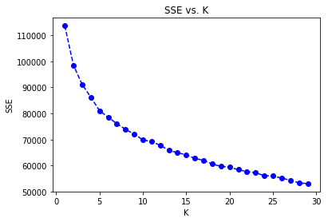

```python
# plot the result
plot_cluster (centers, scores)
```

The features we decided to keep to fit into the model are: ['gender', 'difficulty', 'duration', 'offer_type', 'offer_reward', 'income', 'age', 'loyalty', 'channel']

Number of clusers: 5

```python
# get clusters of data points based on model:
general_prediction = fit_kmeans(features_final, 5)
```

```python
# method to inverse transform data of selected cluster:
def observe_cluser(k, features_final, predictions):

    original_features = features_final[predictions == k]
    inverse_feature = scaler.inverse_transform(original_features[numerical])
    original_features[numerical] = inverse_feature

    original_features['gender'] = original_features['gender'].map({0:'M', 1:'F', 2:'O'})
    original_features['offer_type'] = original_features['offer_type'].map({0:'bogo', 1:'discount'})
    return pd.DataFrame(original_features, columns=features_final.columns)
```

```python
# get all cluster for plotting:
cluster_1 = observe_cluser(0, features_final, general_prediction)
cluster_2 = observe_cluser(1, features_final, general_prediction)
cluster_3 = observe_cluser(2, features_final, general_prediction)
cluster_4 = observe_cluser(3, features_final, general_prediction)
cluster_5 = observe_cluser(4, features_final, general_prediction)
```

```python
cluster_1.describe()
```

|  | difficulty | duration | offer_reward | email | mobile | social | web | completion_time | income_group_30-40K | income_group_40-50K | income_group_50-60K | income_group_60-70K | income_group_70-80K | income_group_80K+ | age_group_Teens | age_group_Young Adults | age_group_Adults | age_group_Middle-aged | age_group_Elders | loyalty_1 | loyalty_2 | loyalty_3 | loyalty_4 | loyalty_5 | loyalty_6 |
| --- | --- | --- | --- | --- | --- | --- | --- | --- | --- | --- | --- | --- | --- | --- | --- | --- | --- | --- | --- | --- | --- | --- | --- | --- | --- |
| count | 6284.000000 | 6284.000000 | 6284.000000 | 6284.0 | 6284.0 | 6284.000000 | 6284.0 | 6284.000000 | 6284.000000 | 6284.000000 | 6284.000000 | 6284.000000 | 6284.000000 | 6284.000000 | 6284.000000 | 6284.000000 | 6284.000000 | 6284.000000 | 6284.0 | 6284.000000 | 6284.000000 | 6284.000000 | 6284.000000 | 6284.000000 | 6284.000000 |
| mean | 0.260895 | 0.619223 | 0.045274 | 1.0 | 1.0 | 0.727562 | 1.0 | 0.387119 | 0.152451 | 0.151496 | 0.378262 | 0.018300 | 0.131445 | 0.168046 | 0.109325 | 0.183004 | 0.271006 | 0.436665 | 0.0 | 0.172502 | 0.368714 | 0.242362 | 0.133355 | 0.058243 | 0.024825 |
| std | 0.096134 | 0.288944 | 0.060084 | 0.0 | 0.0 | 0.445249 | 0.0 | 0.116802 | 0.359486 | 0.358560 | 0.484992 | 0.134046 | 0.337913 | 0.373937 | 0.312072 | 0.386701 | 0.444514 | 0.496012 | 0.0 | 0.377846 | 0.482495 | 0.428546 | 0.339985 | 0.234221 | 0.155604 |
| min | 0.133333 | 0.400000 | 0.000000 | 1.0 | 1.0 | 0.000000 | 1.0 | 0.255935 | 0.000000 | 0.000000 | 0.000000 | 0.000000 | 0.000000 | 0.000000 | 0.000000 | 0.000000 | 0.000000 | 0.000000 | 0.0 | 0.000000 | 0.000000 | 0.000000 | 0.000000 | 0.000000 | 0.000000 |
| 25% | 0.133333 | 0.400000 | 0.000000 | 1.0 | 1.0 | 0.000000 | 1.0 | 0.255935 | 0.000000 | 0.000000 | 0.000000 | 0.000000 | 0.000000 | 0.000000 | 0.000000 | 0.000000 | 0.000000 | 0.000000 | 0.0 | 0.000000 | 0.000000 | 0.000000 | 0.000000 | 0.000000 | 0.000000 |
| 50% | 0.333333 | 0.400000 | 0.000000 | 1.0 | 1.0 | 1.000000 | 1.0 | 0.371428 | 0.000000 | 0.000000 | 0.000000 | 0.000000 | 0.000000 | 0.000000 | 0.000000 | 0.000000 | 0.000000 | 0.000000 | 0.0 | 0.000000 | 0.000000 | 0.000000 | 0.000000 | 0.000000 | 0.000000 |
| 75% | 0.333333 | 1.000000 | 0.125000 | 1.0 | 1.0 | 1.000000 | 1.0 | 0.528860 | 0.000000 | 0.000000 | 1.000000 | 0.000000 | 0.000000 | 0.000000 | 0.000000 | 0.000000 | 1.000000 | 1.000000 | 0.0 | 0.000000 | 1.000000 | 0.000000 | 0.000000 | 0.000000 | 0.000000 |
| max | 0.333333 | 1.000000 | 0.125000 | 1.0 | 1.0 | 1.000000 | 1.0 | 0.528860 | 1.000000 | 1.000000 | 1.000000 | 1.000000 | 1.000000 | 1.000000 | 1.000000 | 1.000000 | 1.000000 | 1.000000 | 0.0 | 1.000000 | 1.000000 | 1.000000 | 1.000000 | 1.000000 | 1.000000 |

```python
cluster_1.head()
```

|  | gender | difficulty | duration | offer_type | offer_reward | email | mobile | social | web | completion_time | income_group_30-40K | income_group_40-50K | income_group_50-60K | income_group_60-70K | income_group_70-80K | income_group_80K+ | age_group_Teens | age_group_Young Adults | age_group_Adults | age_group_Middle-aged | age_group_Elders | loyalty_1 | loyalty_2 | loyalty_3 | loyalty_4 | loyalty_5 | loyalty_6 |
| --- | --- | --- | --- | --- | --- | --- | --- | --- | --- | --- | --- | --- | --- | --- | --- | --- | --- | --- | --- | --- | --- | --- | --- | --- | --- | --- | --- |
| 162 | M | 0.333333 | 1.0 | discount | 0.000 | 1.0 | 1.0 | 1.0 | 1.0 | 0.528860 | 0.0 | 0.0 | 1.0 | 0.0 | 0.0 | 0.0 | 0.0 | 0.0 | 1.0 | 0.0 | 0.0 | 0.0 | 0.0 | 0.0 | 0.0 | 0.0 | 1.0 |
| 171 | M | 0.333333 | 1.0 | discount | 0.000 | 1.0 | 1.0 | 1.0 | 1.0 | 0.528860 | 0.0 | 0.0 | 1.0 | 0.0 | 0.0 | 0.0 | 0.0 | 0.0 | 1.0 | 0.0 | 0.0 | 0.0 | 0.0 | 0.0 | 0.0 | 0.0 | 1.0 |
| 234 | M | 0.133333 | 0.4 | discount | 0.125 | 1.0 | 1.0 | 1.0 | 1.0 | 0.255935 | 0.0 | 0.0 | 0.0 | 1.0 | 0.0 | 0.0 | 1.0 | 0.0 | 0.0 | 0.0 | 0.0 | 0.0 | 1.0 | 0.0 | 0.0 | 0.0 | 0.0 |
| 318 | F | 0.133333 | 0.4 | discount | 0.125 | 1.0 | 1.0 | 1.0 | 1.0 | 0.255935 | 0.0 | 0.0 | 1.0 | 0.0 | 0.0 | 0.0 | 0.0 | 1.0 | 0.0 | 0.0 | 0.0 | 0.0 | 1.0 | 0.0 | 0.0 | 0.0 | 0.0 |
| 332 | F | 0.333333 | 1.0 | discount | 0.000 | 1.0 | 1.0 | 1.0 | 1.0 | 0.528860 | 0.0 | 0.0 | 1.0 | 0.0 | 0.0 | 0.0 | 0.0 | 1.0 | 0.0 | 0.0 | 0.0 | 0.0 | 1.0 | 0.0 | 0.0 | 0.0 | 0.0 |

The data above doesn't say much about the cluster, let's see how well we did by looking at the following Sunburst clusters visualization:

```python
# method to get the cluster data ready for Sunburst plot:
def get_cluster_data(cluster, i , groups, sub_groups):
    cluster_name = 'Cluster_' + str(i)
    labels = [cluster_name]
    parents = ['']
    values = [cluster.shape[0]]
    bin_size = cluster.shape[0]

    for group in groups:
        data = cluster.groupby([group])[group].count().sort_values()
        group_label = [group]
        group_value = [bin_size]

        parents.append(cluster_name)

        group_label.extend((data.index.astype(str)).tolist())
        length = len(group_label)-1

        group_value.extend((data.values).tolist())
        labels.extend(group_label)
        values.extend(group_value)
        length = len(group_label)-1
        parents.extend([group] * length)

    for pair in sub_groups.keys():
        group_label = [pair]
        group_value = [bin_size]
        parents.append(cluster_name)

        for group in sub_groups[pair]:
            data = cluster[group].sum()
            if (pair != 'channel'):
                group_label.append(group[len(pair)+1:])
            else: group_label.append(group)
            group_value.append(data)
            parents.append(pair)

        labels.extend(group_label)
        values.extend(group_value)
    return labels, parents, values
```

```python
groups = ['gender', 'difficulty', 'duration', 'offer_type', 'offer_reward']

sub_groups = {'income': ['income_group_30-40K',
       'income_group_40-50K', 'income_group_50-60K', 'income_group_60-70K',
       'income_group_70-80K', 'income_group_80K+'],
            'age': ['age_group_Teens',
       'age_group_Young Adults', 'age_group_Adults', 'age_group_Middle-aged',
       'age_group_Elders'],
             'loyalty': ['loyalty_1', 'loyalty_2', 'loyalty_3', 'loyalty_4',
       'loyalty_5', 'loyalty_6'],
             'channel': ['email', 'mobile', 'social', 'web']}
```

```python
# get cluster sunburst data: labels, parents and values:
c1_labels, c1_parents, cl_values = get_cluster_data(cluster_1, 1,groups, sub_groups)
c2_labels, c2_parents, c2_values = get_cluster_data(cluster_2, 2,groups, sub_groups)
c3_labels, c3_parents, c3_values = get_cluster_data(cluster_3, 3,groups, sub_groups)
c4_labels, c4_parents, c4_values = get_cluster_data(cluster_4, 4,groups, sub_groups)
c5_labels, c5_parents, c5_values = get_cluster_data(cluster_5, 5,groups, sub_groups)
```

```python
# sanity check
test_m = [c1_labels, c1_parents, cl_values]
pd.DataFrame(test_m)
```

|  | 0 | 1 | 2 | 3 | 4 | 5 | 6 | 7 | 8 | 9 | 10 | 11 | 12 | 13 | 14 | 15 | 16 | 17 | 18 | 19 | 20 | 21 | 22 | 23 | 24 | 25 | 26 | 27 | 28 | … |
| --- | --- | --- | --- | --- | --- | --- | --- | --- | --- | --- | --- | --- | --- | --- | --- | --- | --- | --- | --- | --- | --- | --- | --- | --- | --- | --- | --- | --- | --- | --- |
| 0 | Cluster_1 | gender | O | F | M | difficulty | 0.13333333333333336 | 0.3333333333333333 | duration | 1.0 | 0.40000000000000013 | offer_type | discount | offer_reward | 0.125 | 0.0 | income | group_30-40K | group_40-50K | group_50-60K | group_60-70K | group_70-80K | group_80K+ | age | group_Teens | group_Young Adults | group_Adults | group_Middle-aged | group_Elders | … |
| 1 |  | Cluster_1 | gender | gender | gender | Cluster_1 | difficulty | difficulty | Cluster_1 | duration | duration | Cluster_1 | offer_type | Cluster_1 | offer_reward | offer_reward | Cluster_1 | income | income | income | income | income | income | Cluster_1 | age | age | age | age | age | … |
| 2 | 6284 | 6284 | 84 | 2524 | 3676 | 6284 | 2276 | 4008 | 6284 | 2296 | 3988 | 6284 | 6284 | 6284 | 2276 | 4008 | 6284 | 958 | 952 | 2377 | 115 | 826 | 1056 | 6284 | 687 | 1150 | 1703 | 2744 | 0 | … |

```python
# plot each cluster as Sunburst, where the possible values are leaf of the main herarichy
trace1 = go.Sunburst(
    labels= c1_labels,
    parents= c1_parents,
    values= cl_values,
    name = 'Cluster 1',
    #branchvalues="total",
    outsidetextfont = {"size": 20, "color": "#377eb8"},
    marker = {"line": {"width": 2}},
    domain=dict(column=0, row=0)
)

trace2 = go.Sunburst(
    labels= c2_labels,
    parents= c2_parents,
    values= c2_values,
    name = 'Cluster 2',
    #branchvalues="total",
    outsidetextfont = {"size": 20, "color": "#377eb8"},
    marker = {"line": {"width": 2}},
    domain=dict(column=0, row=0)
)

trace3 = go.Sunburst(
    labels= c3_labels,
    parents= c3_parents,
    values= c3_values,
    name = 'Cluster 3',
    #branchvalues="total",
    outsidetextfont = {"size": 20, "color": "#377eb8"},
    marker = {"line": {"width": 2}},
    domain=dict(column=0, row=0)
)

trace4 = go.Sunburst(
    labels= c4_labels,
    parents= c4_parents,
    values= c4_values,
    name = 'Cluster 4',
    #branchvalues="total",
    outsidetextfont = {"size": 20, "color": "#377eb8"},
    marker = {"line": {"width": 2}},
    domain=dict(column=0, row=0)
)

trace5 = go.Sunburst(
    labels= c5_labels,
    parents= c5_parents,
    values= c5_values,
    name = 'Cluster 5',
    #branchvalues="total",
    outsidetextfont = {"size": 20, "color": "#377eb8"},
    marker = {"line": {"width": 2}},
    domain=dict(column=0, row=0)
)


layout = go.Layout(
    margin = go.layout.Margin(t=0, l=0, r=0, b=0),
    grid=go.layout.Grid(columns=2, rows=1),
    sunburstcolorway=["#636efa","#ef553b","#00cc96",
    "#636efa","#EF553B","#00cc96","#ab63fa","#19d3f3",
    "#e763fa", "#FECB52","#FFA15A","#FF6692","#B6E880"
  ],
    extendsunburstcolors=True
)
```

```python
fig = go.Figure([trace1], layout)

py.iplot(fig, filename='cluster_sunburst_1')
```

[interactive chart not shown]

```python
fig = go.Figure([trace2], layout)

py.iplot(fig, filename='cluster_sunburst_2')
```

[interactive chart not shown]

```python
fig = go.Figure([trace3], layout)

py.iplot(fig, filename='cluster_sunburst_3')
```

[interactive chart not shown]

```python
fig = go.Figure([trace4], layout)

py.iplot(fig, filename='cluster_sunburst_4')
```

[interactive chart not shown]

```python
fig = go.Figure([trace5], layout)

py.iplot(fig, filename='cluster_sunburst_5')
```

[interactive chart not shown]

#### General Observation and Reflection from KMeans Clusters:

1. Channel was not necessary feature since it doesn't yeald any data on which channel the user interacted with.
2. Age and Income, play major rule in creating the clusters. Whereas the remaining features are somewhat less important.
3. It's clear that clusters where based on Offer Type, so it's interesting to see which customer groups interacted well with which offer.
4. We should be wary of any biases in the dataset, as we didn't confirm any inbalance in the sent offers of each type.

## Conclusion and Future Enhancements:

1. The analysis confirms our inital theaory that custmers behave in certain way and we can target it to our advantage.
2. Clustering is great way to understand custumer segments in commerce, further we may want to experiment with different clustring algorithms.
3. The dataset is very limited in information, having more details such as; the type of purchased items, timestamp of transactions, branch location, custmer home location, would even drive far more interesting results.
4. There are many challenging features to this dataset that limited our anlysis. For examples, we do not any link between transactions and offer, a custmer may purchase a product without the influence of an offer, yet when the offer is completed it is accounted in our model dataset. This can be solved by learning to identify customer bahaviour and purchase habits whether it is out of the usual or just a simple routine.

References:

- https://hlab.stanford.edu/brian/error_sum_of_squares.html
- https://plot.ly/python/v3/sunburst-charts/
- https://stackoverflow.com/questions/45312377/how-to-one-hot-encode-from-a-pandas-column-containing-a-list
- https://stackoverflow.com/questions/38231591/splitting-dictionary-list-inside-a-pandas-column-into-separate-columns
- https://stackoverflow.com/questions/34165876/trying-to-create-grouped-variable-in-python